# Case Study 11 : Interacting with Time

TomHollinberger

11/6/2020

THIS RSCRIPT USES ROXYGEN CHARACTERS.  
YOU CAN PRESS ctrl+shift+K AND GO STRAIGHT TO A HTML.  
SKIPS THE HANDWORK OF CREATING A RMD, AFTER THE ORIGINAL WORK IS NONE IN A RSCRIPT.

### DYGRAPHS DESCRIPTION :

The dygraphs are laid out in a three tier arrangment for easy comparison of growth of a dollar, percent growth, and actual stock price.  
They are syncronized so that a zoom-in on one will automatically be reflected in the other two. There is a Reset Zoom function that turns-on in the upper left after a zoom has occurred. The legend has been set to width=100, so that it sits in a vertical column for easier reading. There is a range-selector at the bottom, which is also syncronized between the three graphs. The range selector is enlarged and has a red topline for easy “where am I” interpretation. There is a rolling average selector in the lower left, which is initially set to 5 to help smooth the lines for easier reading. Data lines are set to magnify when hovered on, and other datalines fade.  
There are also datadots and crosshairs that appear as the mouse hovers. These aid in reading across to axis values associated with particular datapoints. Grid color is set to gold, so as to not visually interfere with the datalines or the crosshairs. The period start date is built-in via formula to the main title. Note: In this unique case, JCPenney data is incomplete, which hampers the value-growth and percentage growth calculations.

### GGPLOT DESCRIPTION :

Based on internet research on how to use stock sales volume to inform stock purchases, a template graph was developed.  
This template is applied to each individual stock. These individual graphs help compare a particular stock sales volume to its share price over time.  
In order to facilitate comparison of stock price and sales volume behaviors, which are usually on vastly different numeric scales, the price and volume amounts were standardized using the “scale” function. The graphs now show standard deviations from the mean price or mean volume on the vertical dimension. A red horizontal zero line shows the mean. At a glance, the reader can see whether they are above or below average price or volume, and the magnitudes are now on comparable scales.  
The daily data is very busy, so 5-day moving average lines are added, using geom_ma, in their corresponding color, but with some transparency. Visual interpretation and professional judgment can then be applied to make a buy/don’t buy recommendations.  
Patterns and relationships between Price and Volume are mentioned in https://www.investopedia.com/articles/technical/02/010702.asp and can be easily identified in the graphs.

```r
######
```

[ ] Use library(dygraphs) to build interactive visualizations of the stock performances over the last 5 years.

```r
# Load packages
library(quantmod)
library(tidyquant) # to get stock data
library(tidyverse) # for pipes
library(dplyr) # for data transformations
library(lubridate) # for date/time functions
library(timetk) # for converting dates to xts
```

```r
library(dygraphs) # for interactive plots
#install this plugin to enable crosshairs
dyCrosshair <- function(dygraph,
                        direction = c("both", "horizontal", "vertical")) {
  dyPlugin(
    dygraph = dygraph,
    name = "Crosshair",
    path = system.file("plugins/crosshair.js",
                       package = "dygraphs"),
    options = list(direction = match.arg(direction))
  )
}

#install this plugin to enable UNZOOM
dyUnzoom <-function(dygraph) {
  dyPlugin(
    dygraph = dygraph,
    name = "Unzoom",
    path = system.file("plugins/unzoom.js", package = "dygraphs")
  )
}

# Tickers and Pull Data
#Manually enter tickers
tickers_today <- c("CXW", "F", "GM", "JCPNQ", "KR", "WDC", "NKE","T", "WDAY", "WFC", "WMT")
#note: JCP is JCPNQ while they are in bankruptcy, and has no data until Nov2019
x1 <- tickers_today[1]
x2 <- tickers_today[2]
x3 <- tickers_today[3]
x4 <- tickers_today[4]
x5 <- tickers_today[5]
x6 <- tickers_today[6]
x7 <- tickers_today[7]
x8 <- tickers_today[8]
x9 <- tickers_today[9]
x10 <- tickers_today[10]
x11 <- tickers_today[11]

end <- today() - days(3)    #manually set date window, eg, a rolling two year retrospective, ending three days ago
start <- end - years(2)

x1_prices <- tq_get(x1, get = "stock.prices", from = start, to = end)
x2_prices <- tq_get(x2, get = "stock.prices", from = start, to = end)
x3_prices <- tq_get(x3, get = "stock.prices", from = start, to = end)
x4_prices <- tq_get(x4, get = "stock.prices", from = start, to = end)
x5_prices <- tq_get(x5, get = "stock.prices", from = start, to = end)
x6_prices <- tq_get(x6, get = "stock.prices", from = start, to = end)
x7_prices <- tq_get(x7, get = "stock.prices", from = start, to = end)
x8_prices <- tq_get(x8, get = "stock.prices", from = start, to = end)
x9_prices <- tq_get(x9, get = "stock.prices", from = start, to = end)
x10_prices <- tq_get(x10, get = "stock.prices", from = start, to = end)
x11_prices <- tq_get(x11, get = "stock.prices", from = start, to = end)

My_stockPrices <- bind_rows(x1_prices, x2_prices, x3_prices, x4_prices, x5_prices, x6_prices, x7_prices, x8_prices, x9_prices, x10_prices, x11_prices) %>%
  select(symbol, date, adjusted) %>%
  pivot_wider(names_from = symbol, values_from = adjusted) %>%
  tk_xts(date_var = date)
My_stockPrices
```

[output not shown]

[output cut: 951 more lines]

```
## 2020-10-13 27.75000 232.90 24.62693 146.23000
## 2020-10-14 27.49000 230.54 23.14374 143.94000
## 2020-10-15 27.45000 226.67 22.84511 144.53000
## 2020-10-16 27.33000 229.45 22.75552 144.71001
## 2020-10-19 26.88000 227.64 22.43698 142.95000
## 2020-10-20 26.76000 224.43 22.70575 143.89999
## 2020-10-21 26.72000 224.31 22.59625 144.39999
## 2020-10-22 28.28000 220.85 23.14374 143.55000
## 2020-10-23 27.82000 224.14 23.17360 143.85001
## 2020-10-26 27.38000 210.33 22.59625 142.16000
## 2020-10-27 26.92000 214.17 21.72027 142.86999
## 2020-10-28 26.50000 209.70 21.08320 140.03999
## 2020-10-29 26.76000 217.63 21.04338 139.92000
## 2020-10-30 27.02000 210.12 21.35197 138.75000
## 2020-11-02 27.34000 205.48 21.79991 140.39999
```

```r
invamt <- 100  #manually input the initial investment amount
```

## Three Useful **dyGraphs of Stock Performance**, grouped for syncronized zooming

```r
dygraph(My_stockPrices, main = paste("Value of an initial $",invamt,", invested on", start), group = "stock2") %>%  #this assumes no missing values, which would delay the start of accumulation calcs.
  dyRebase(value = invamt) %>%
  dyRangeSelector() %>%
  dyHighlight(highlightSeriesOpts = list(strokeWidth = 3)) %>%
  dyLegend(width = 100) %>%
  dyRoller(rollPeriod = 5) %>%
  dyRangeSelector(dateWindow = c(start, end),height = 100, strokeColor = "red") %>%   #or "yyy-mm-dd" or with no RangeSelector(dateWindow) command,or RangeSelector()  it inherits the extent of the "get"
  dyCrosshair(direction = "both") %>%
  dyUnzoom() %>%
  dyOptions(gridLineColor = "Gold")
```

[interactive chart not shown]

```r
dygraph(My_stockPrices, main = paste("Percent Growth since",start), group = "stock2") %>%
  dyRebase(percent = TRUE) %>%
  dyRangeSelector() %>%
  dyHighlight(highlightSeriesOpts = list(strokeWidth = 3)) %>%
  dyLegend(width = 100) %>%
  dyRoller(rollPeriod = 5) %>%
  dyRangeSelector(dateWindow = c(start, end),height = 100, strokeColor = "red") %>%
  dyCrosshair(direction = "both") %>%
  dyUnzoom() %>%
  dyOptions(gridLineColor = "Gold")
```

[interactive chart not shown]

```r
dygraph(My_stockPrices, main = "Stock Price, Adjusted End of Day", group = "stock2") %>%
  dyRangeSelector()  %>%
  dyHighlight(highlightSeriesOpts = list(strokeWidth = 3)) %>%
  dyLegend(width = 100) %>%
  dyRoller(rollPeriod = 5) %>%
  dyRangeSelector(dateWindow = c(start, end),height = 100, strokeColor = "red") %>%
  dyCrosshair(direction = "both") %>%
  dyUnzoom() %>%
  dyOptions(gridLineColor = "Gold")
```

[interactive chart not shown]

```r
#how to plot in viewer multi-tiered   CAN ONLY BE SEEN IN RMD, must knit first
# from https://github.com/rstudio/dygraphs/issues/59
```

[ ] Make a library(ggplot2) graphic that helps you build a solid question around how an investor would use volume in their trading strategy.

```r
# How to use volume to improve trading strategy
# https://www.investopedia.com/articles/technical/02/010702.asp
# KEY TAKEAWAYS
# Volume measures the number of shares traded in a stock or contracts traded in futures or options.
# Volume can be an indicator of market strength, as rising markets on increasing volume are typically viewed as strong and healthy.
# When prices fall on increasing volume, the trend is gathering strength to the downside. (BAD)
# When prices reach new highs (or no lows) on decreasing volume, watch out; a reversal might be taking shape. (BAD)
# Look for rising prices on rising volume.
# Look for reaching new price lows on decreasing volume (it will turn around)


My_stockVolume <- bind_rows(x1_prices, x2_prices, x3_prices, x4_prices, x5_prices, x6_prices, x7_prices, x8_prices, x9_prices, x10_prices, x11_prices)
AllMy_stockAdjVol <-  select(My_stockVolume, symbol, date, adjusted, volume)
AllMy_stockAdjVol
```

```
## # A tibble: 5,260 x 4
##    symbol date       adjusted  volume
##    <chr>  <date>        <dbl>   <dbl>
##  1 CXW    2018-11-05     20.0  819100
##  2 CXW    2018-11-06     18.6 1612600
##  3 CXW    2018-11-07     18.8  775000
##  4 CXW    2018-11-08     19.0  524200
##  5 CXW    2018-11-09     18.7  584500
##  6 CXW    2018-11-12     19.4  734000
##  7 CXW    2018-11-13     19.3  297600
##  8 CXW    2018-11-14     18.9  636900
##  9 CXW    2018-11-15     18.6  576000
## 10 CXW    2018-11-16     18.3 1206900
## # ... with 5,250 more rows
```

```r
#Template for standardizing the volume and adjusted columns for each individual stock, since we will be comparing their movements, but they have very different scales.
#Do this just prior to each graph

#Particular_stock <- filter(AllMy_stockAdjVol , symbol == "XYZ")
#Particular_stock$volstd <- scale(Particular_stock$volume)
#Particular_stock$adjstd <- scale(Particular_stock$adjusted)
#Particular_stock




adjvolCXW <- filter(AllMy_stockAdjVol , symbol == "CXW")
adjvolCXW
```

```
## # A tibble: 502 x 4
##    symbol date       adjusted  volume
##    <chr>  <date>        <dbl>   <dbl>
##  1 CXW    2018-11-05     20.0  819100
##  2 CXW    2018-11-06     18.6 1612600
##  3 CXW    2018-11-07     18.8  775000
##  4 CXW    2018-11-08     19.0  524200
##  5 CXW    2018-11-09     18.7  584500
##  6 CXW    2018-11-12     19.4  734000
##  7 CXW    2018-11-13     19.3  297600
##  8 CXW    2018-11-14     18.9  636900
##  9 CXW    2018-11-15     18.6  576000
## 10 CXW    2018-11-16     18.3 1206900
## # ... with 492 more rows
```

```r
adjvolCXW$volstd <- scale(adjvolCXW$volume)
adjvolCXW$adjstd <- scale(adjvolCXW$adjusted)
adjvolCXW
```

```
## # A tibble: 502 x 6
##    symbol date       adjusted  volume volstd[,1] adjstd[,1]
##    <chr>  <date>        <dbl>   <dbl>      <dbl>      <dbl>
##  1 CXW    2018-11-05     20.0  819100    -0.219        1.46
##  2 CXW    2018-11-06     18.6 1612600     0.332        1.10
##  3 CXW    2018-11-07     18.8  775000    -0.250        1.15
##  4 CXW    2018-11-08     19.0  524200    -0.424        1.19
##  5 CXW    2018-11-09     18.7  584500    -0.382        1.12
##  6 CXW    2018-11-12     19.4  734000    -0.279        1.31
##  7 CXW    2018-11-13     19.3  297600    -0.582        1.27
##  8 CXW    2018-11-14     18.9  636900    -0.346        1.16
##  9 CXW    2018-11-15     18.6  576000    -0.388        1.09
## 10 CXW    2018-11-16     18.3 1206900     0.0498       1.02
## # ... with 492 more rows
```

## Stock Purchase Recommendations based on **Volume Analysis**

### CXW Recommendation: Buy, due to low price and decreased volume.

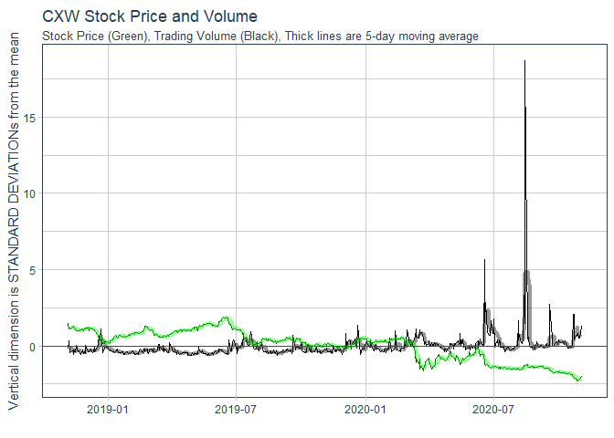

```r
adjvolCXW %>%
  ggplot() +
  geom_line(aes(x = date, y = volstd)) +
  geom_line(aes(x = date, y = adjstd), color = "dark green") +
  geom_ma(aes(x = date, y = volstd), n = 5, color = "black", size = 1.5, linetype = 1, alpha = .4) +
  geom_ma(aes(x = date, y = adjstd), n = 5, color = "green", size = 1.5, linetype = 1, alpha = .4) +
  geom_hline(yintercept = 0, color = "red") +
  labs(title = "CXW Stock Price and Volume",
       subtitle = "Stock Price (Green), Trading Volume (Black), Thick lines are 5-day moving average",
       y = "Vertical dimension is STANDARD DEVIATIONs from the mean",
       x = "") +
  theme_tq()
```

```r
adjvolF <- filter(AllMy_stockAdjVol, symbol == "F")
adjvolF
```

```
## # A tibble: 502 x 4
##    symbol date       adjusted   volume
##    <chr>  <date>        <dbl>    <dbl>
##  1 F      2018-11-05     8.79 41274300
##  2 F      2018-11-06     8.80 40928600
##  3 F      2018-11-07     8.85 37347400
##  4 F      2018-11-08     8.72 55810100
##  5 F      2018-11-09     8.65 52203600
##  6 F      2018-11-12     8.75 36317200
##  7 F      2018-11-13     8.80 33098000
##  8 F      2018-11-14     8.80 46677600
##  9 F      2018-11-15     8.58 57170100
## 10 F      2018-11-16     8.34 54582500
## # ... with 492 more rows
```

```r
adjvolF$volstd <- scale(adjvolF$volume)
adjvolF$adjstd <- scale(adjvolF$adjusted)
adjvolF
```

```
## # A tibble: 502 x 6
##    symbol date       adjusted   volume volstd[,1] adjstd[,1]
##    <chr>  <date>        <dbl>    <dbl>      <dbl>      <dbl>
##  1 F      2018-11-05     8.79 41274300   -0.485        0.641
##  2 F      2018-11-06     8.80 40928600   -0.496        0.648
##  3 F      2018-11-07     8.85 37347400   -0.613        0.687
##  4 F      2018-11-08     8.72 55810100   -0.00973      0.595
##  5 F      2018-11-09     8.65 52203600   -0.128        0.543
##  6 F      2018-11-12     8.75 36317200   -0.647        0.615
##  7 F      2018-11-13     8.80 33098000   -0.752        0.648
##  8 F      2018-11-14     8.80 46677600   -0.308        0.648
##  9 F      2018-11-15     8.58 57170100    0.0347       0.497
## 10 F      2018-11-16     8.34 54582500   -0.0498       0.327
## # ... with 492 more rows
```

### F Recommendation: Don’t Buy, due to price recently climbing and recently high volume.

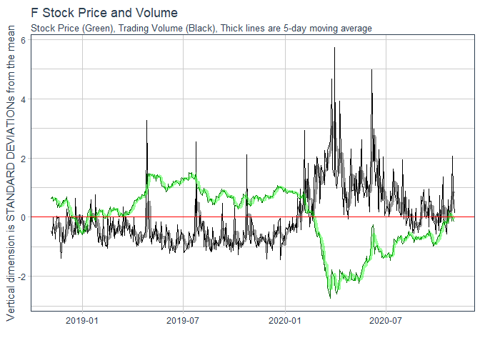

```r
adjvolF %>%
  ggplot() +
  geom_line(aes(x = date, y = volstd)) +
  geom_line(aes(x = date, y = adjstd), color = "dark green") +
  geom_ma(aes(x = date, y = volstd), n = 5, color = "black", size = 1.5, linetype = 1, alpha = .4) +
  geom_ma(aes(x = date, y = adjstd), n = 5, color = "green", size = 1.5, linetype = 1, alpha = .4) +
  geom_hline(yintercept = 0, color = "red") +
  labs(title = "F Stock Price and Volume",
       subtitle = "Stock Price (Green), Trading Volume (Black), Thick lines are 5-day moving average",
       y = "Vertical dimension is STANDARD DEVIATIONs from the mean",
       x = "") +
  theme_tq()
```

```r
adjvolGM <- filter(AllMy_stockAdjVol, symbol == "GM")
adjvolGM
```

```
## # A tibble: 502 x 4
##    symbol date       adjusted   volume
##    <chr>  <date>        <dbl>    <dbl>
##  1 GM     2018-11-05     34.0 11477100
##  2 GM     2018-11-06     34.2 11187700
##  3 GM     2018-11-07     34.6  9457800
##  4 GM     2018-11-08     34.3 10807900
##  5 GM     2018-11-09     33.5  9037500
##  6 GM     2018-11-12     33.5 10062100
##  7 GM     2018-11-13     33.7  8594000
##  8 GM     2018-11-14     33.1 10883400
##  9 GM     2018-11-15     33.4 17675600
## 10 GM     2018-11-16     33.5 11681500
## # ... with 492 more rows
```

```r
adjvolGM$volstd <- scale(adjvolGM$volume)
adjvolGM$adjstd <- scale(adjvolGM$adjusted)
adjvolGM
```

```
## # A tibble: 502 x 6
##    symbol date       adjusted   volume volstd[,1] adjstd[,1]
##    <chr>  <date>        <dbl>    <dbl>      <dbl>      <dbl>
##  1 GM     2018-11-05     34.0 11477100    -0.0543     0.269
##  2 GM     2018-11-06     34.2 11187700    -0.102      0.307
##  3 GM     2018-11-07     34.6  9457800    -0.387      0.384
##  4 GM     2018-11-08     34.3 10807900    -0.165      0.327
##  5 GM     2018-11-09     33.5  9037500    -0.457      0.168
##  6 GM     2018-11-12     33.5 10062100    -0.288      0.166
##  7 GM     2018-11-13     33.7  8594000    -0.530      0.210
##  8 GM     2018-11-14     33.1 10883400    -0.152      0.0816
##  9 GM     2018-11-15     33.4 17675600     0.968      0.140
## 10 GM     2018-11-16     33.5 11681500    -0.0206     0.177
## # ... with 492 more rows
```

### GM Recommendation: Don’t Buy, because of recently risen prices and decreasing volume.

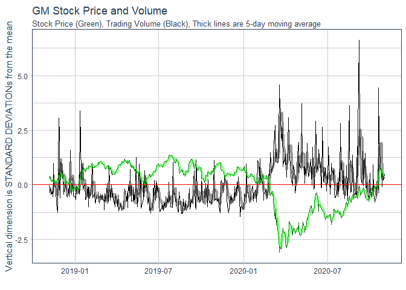

```r
adjvolGM %>%
  ggplot() +
  geom_line(aes(x = date, y = volstd)) +
  geom_line(aes(x = date, y = adjstd), color = "dark green") +
  geom_ma(aes(x = date, y = volstd), n = 5, color = "black", size = 1.5, linetype = 1, alpha = .4) +
  geom_ma(aes(x = date, y = adjstd), n = 5, color = "green", size = 1.5, linetype = 1, alpha = .4) +
  geom_hline(yintercept = 0, color = "red") +
  labs(title = "GM Stock Price and Volume",
       subtitle = "Stock Price (Green), Trading Volume (Black), Thick lines are 5-day moving average",
       y = "Vertical dimension is STANDARD DEVIATIONs from the mean",
       x = "") +
  theme_tq()
```

```r
adjvolJCPNQ <- filter(AllMy_stockAdjVol, symbol == "JCPNQ")
adjvolJCPNQ
```

```
## # A tibble: 240 x 4
##    symbol date       adjusted  volume
##    <chr>  <date>        <dbl>   <dbl>
##  1 JCPNQ  2019-11-20     1.11 8186600
##  2 JCPNQ  2019-11-21     1.08 8293900
##  3 JCPNQ  2019-11-22     1.1  6240100
##  4 JCPNQ  2019-11-25     1.15 8827900
##  5 JCPNQ  2019-11-26     1.17 7513900
##  6 JCPNQ  2019-11-27     1.11 7628100
##  7 JCPNQ  2019-11-29     1.13 2741300
##  8 JCPNQ  2019-12-02     1.1  6139400
##  9 JCPNQ  2019-12-03     1.13 3463700
## 10 JCPNQ  2019-12-04     1.14 5375300
## # ... with 230 more rows
```

```r
adjvolJCPNQ$volstd <- scale(adjvolJCPNQ$volume)
adjvolJCPNQ$adjstd <- scale(adjvolJCPNQ$adjusted)
adjvolJCPNQ
```

```
## # A tibble: 240 x 6
##    symbol date       adjusted  volume volstd[,1] adjstd[,1]
##    <chr>  <date>        <dbl>   <dbl>      <dbl>      <dbl>
##  1 JCPNQ  2019-11-20     1.11 8186600     -0.243       1.94
##  2 JCPNQ  2019-11-21     1.08 8293900     -0.238       1.84
##  3 JCPNQ  2019-11-22     1.1  6240100     -0.337       1.91
##  4 JCPNQ  2019-11-25     1.15 8827900     -0.212       2.06
##  5 JCPNQ  2019-11-26     1.17 7513900     -0.275       2.13
##  6 JCPNQ  2019-11-27     1.11 7628100     -0.270       1.94
##  7 JCPNQ  2019-11-29     1.13 2741300     -0.507       2.00
##  8 JCPNQ  2019-12-02     1.1  6139400     -0.342       1.91
##  9 JCPNQ  2019-12-03     1.13 3463700     -0.472       2.00
## 10 JCPNQ  2019-12-04     1.14 5375300     -0.379       2.03
## # ... with 230 more rows
```

### JCPNQ Recommendation: Don’t Buy. They are in bankruptcy, and it’s hard to tell what will happen. Also, recent drop in prices while volume is stable.

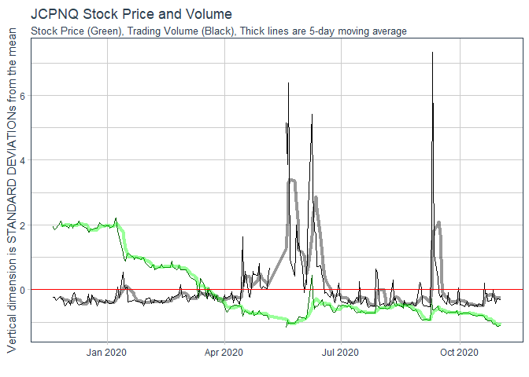

```r
adjvolJCPNQ %>%
  ggplot() +
  geom_line(aes(x = date, y = volstd)) +
  geom_line(aes(x = date, y = adjstd), color = "dark green") +
  geom_ma(aes(x = date, y = volstd), n = 5, color = "black", size = 1.5, linetype = 1, alpha = .4) +
  geom_ma(aes(x = date, y = adjstd), n = 5, color = "green", size = 1.5, linetype = 1, alpha = .4) +
  geom_hline(yintercept = 0, color = "red") +
  labs(title = "JCPNQ Stock Price and Volume",
       subtitle = "Stock Price (Green), Trading Volume (Black), Thick lines are 5-day moving average",
       y = "Vertical dimension is STANDARD DEVIATIONs from the mean",
       x = "") +
  theme_tq()
```

```r
adjvolKR <- filter(AllMy_stockAdjVol, symbol == "KR")
adjvolKR
```

```
## # A tibble: 502 x 4
##    symbol date       adjusted  volume
##    <chr>  <date>        <dbl>   <dbl>
##  1 KR     2018-11-05     29.3 7014600
##  2 KR     2018-11-06     29.5 6082900
##  3 KR     2018-11-07     30.0 7791500
##  4 KR     2018-11-08     30.0 5644000
##  5 KR     2018-11-09     30.1 6935400
##  6 KR     2018-11-12     30.0 5927800
##  7 KR     2018-11-13     30.1 6806100
##  8 KR     2018-11-14     29.1 8510700
##  9 KR     2018-11-15     28.9 5861600
## 10 KR     2018-11-16     29.1 4530900
## # ... with 492 more rows
```

```r
adjvolKR$volstd <- scale(adjvolKR$volume)
adjvolKR$adjstd <- scale(adjvolKR$adjusted)
adjvolKR
```

```
## # A tibble: 502 x 6
##    symbol date       adjusted  volume volstd[,1] adjstd[,1]
##    <chr>  <date>        <dbl>   <dbl>      <dbl>      <dbl>
##  1 KR     2018-11-05     29.3 7014600    -0.371       0.293
##  2 KR     2018-11-06     29.5 6082900    -0.554       0.343
##  3 KR     2018-11-07     30.0 7791500    -0.218       0.454
##  4 KR     2018-11-08     30.0 5644000    -0.640       0.461
##  5 KR     2018-11-09     30.1 6935400    -0.386       0.470
##  6 KR     2018-11-12     30.0 5927800    -0.584       0.465
##  7 KR     2018-11-13     30.1 6806100    -0.412       0.468
##  8 KR     2018-11-14     29.1 8510700    -0.0772      0.252
##  9 KR     2018-11-15     28.9 5861600    -0.597       0.193
## 10 KR     2018-11-16     29.1 4530900    -0.859       0.240
## # ... with 492 more rows
```

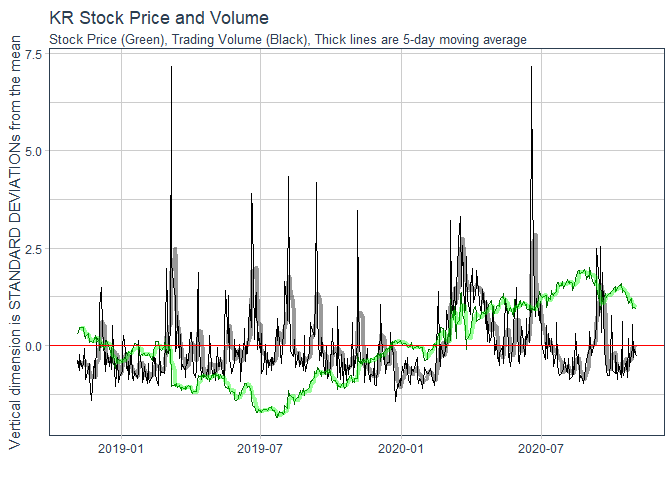

```r
adjvolKR %>%
  ggplot() +
  geom_line(aes(x = date, y = volstd)) +
  geom_line(aes(x = date, y = adjstd), color = "dark green") +
  geom_ma(aes(x = date, y = volstd), n = 5, color = "black", size = 1.5, linetype = 1, alpha = .4) +
  geom_ma(aes(x = date, y = adjstd), n = 5, color = "green", size = 1.5, linetype = 1, alpha = .4) +
  geom_hline(yintercept = 0, color = "red") +
  labs(title = "KR Stock Price and Volume",
       subtitle = "Stock Price (Green), Trading Volume (Black), Thick lines are 5-day moving average",
       y = "Vertical dimension is STANDARD DEVIATIONs from the mean",
       x = "") +
  theme_tq()
```

```r
adjvolWDC <- filter(AllMy_stockAdjVol, symbol == "WDC")
adjvolWDC
```

```
## # A tibble: 502 x 4
##    symbol date       adjusted  volume
##    <chr>  <date>        <dbl>   <dbl>
##  1 WDC    2018-11-05     45.3 5951300
##  2 WDC    2018-11-06     45.8 3667700
##  3 WDC    2018-11-07     45.4 3976000
##  4 WDC    2018-11-08     44.5 3999000
##  5 WDC    2018-11-09     42.8 5726300
##  6 WDC    2018-11-12     40.7 5063300
##  7 WDC    2018-11-13     41.8 6311400
##  8 WDC    2018-11-14     42.2 4376800
##  9 WDC    2018-11-15     43.8 5128900
## 10 WDC    2018-11-16     43.6 3888000
## # ... with 492 more rows
```

```r
adjvolWDC$volstd <- scale(adjvolWDC$volume)
adjvolWDC$adjstd <- scale(adjvolWDC$adjusted)
adjvolWDC
```

```
## # A tibble: 502 x 6
##    symbol date       adjusted  volume volstd[,1] adjstd[,1]
##    <chr>  <date>        <dbl>   <dbl>      <dbl>      <dbl>
##  1 WDC    2018-11-05     45.3 5951300    -0.0104     -0.180
##  2 WDC    2018-11-06     45.8 3667700    -0.699      -0.125
##  3 WDC    2018-11-07     45.4 3976000    -0.606      -0.163
##  4 WDC    2018-11-08     44.5 3999000    -0.599      -0.262
##  5 WDC    2018-11-09     42.8 5726300    -0.0783     -0.449
##  6 WDC    2018-11-12     40.7 5063300    -0.278      -0.682
##  7 WDC    2018-11-13     41.8 6311400     0.0982     -0.556
##  8 WDC    2018-11-14     42.2 4376800    -0.485      -0.519
##  9 WDC    2018-11-15     43.8 5128900    -0.258      -0.347
## 10 WDC    2018-11-16     43.6 3888000    -0.633      -0.360
## # ... with 492 more rows
```

### WDC Recommendation: Buy, because prices have been low for awhile, and volume has been starting to increase. Could be ready to upswing.

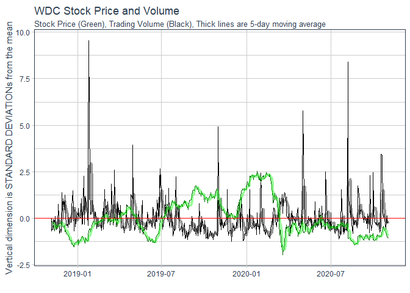

```r
adjvolWDC %>%
  ggplot() +
  geom_line(aes(x = date, y = volstd)) +
  geom_line(aes(x = date, y = adjstd), color = "dark green") +
  geom_ma(aes(x = date, y = volstd), n = 5, color = "black", size = 1.5, linetype = 1, alpha = .4) +
  geom_ma(aes(x = date, y = adjstd), n = 5, color = "green", size = 1.5, linetype = 1, alpha = .4) +
  geom_hline(yintercept = 0, color = "red") +
  labs(title = "WDC Stock Price and Volume",
       subtitle = "Stock Price (Green), Trading Volume (Black), Thick lines are 5-day moving average",
       y = "Vertical dimension is STANDARD DEVIATIONs from the mean",
       x = "") +
  theme_tq()
```

```r
adjvolNKE <- filter(AllMy_stockAdjVol, symbol == "NKE")
adjvolNKE
```

```
## # A tibble: 502 x 4
##    symbol date       adjusted  volume
##    <chr>  <date>        <dbl>   <dbl>
##  1 NKE    2018-11-05     75.9 7143300
##  2 NKE    2018-11-06     75.0 6424200
##  3 NKE    2018-11-07     76.4 5403900
##  4 NKE    2018-11-08     76.2 5425000
##  5 NKE    2018-11-09     74.8 4737600
##  6 NKE    2018-11-12     73.5 5204900
##  7 NKE    2018-11-13     73.6 4584600
##  8 NKE    2018-11-14     73.6 7984200
##  9 NKE    2018-11-15     72.8 7858300
## 10 NKE    2018-11-16     73.2 8064200
## # ... with 492 more rows
```

```r
adjvolNKE$volstd <- scale(adjvolNKE$volume)
adjvolNKE$adjstd <- scale(adjvolNKE$adjusted)
adjvolNKE
```

```
## # A tibble: 502 x 6
##    symbol date       adjusted  volume volstd[,1] adjstd[,1]
##    <chr>  <date>        <dbl>   <dbl>      <dbl>      <dbl>
##  1 NKE    2018-11-05     75.9 7143300     0.0217      -1.09
##  2 NKE    2018-11-06     75.0 6424200    -0.171       -1.16
##  3 NKE    2018-11-07     76.4 5403900    -0.445       -1.06
##  4 NKE    2018-11-08     76.2 5425000    -0.439       -1.08
##  5 NKE    2018-11-09     74.8 4737600    -0.623       -1.18
##  6 NKE    2018-11-12     73.5 5204900    -0.498       -1.27
##  7 NKE    2018-11-13     73.6 4584600    -0.664       -1.26
##  8 NKE    2018-11-14     73.6 7984200     0.247       -1.26
##  9 NKE    2018-11-15     72.8 7858300     0.213       -1.32
## 10 NKE    2018-11-16     73.2 8064200     0.269       -1.29
## # ... with 492 more rows
```

### NKE Recommendation: Don’t Buy, because prices are higher than ever and just truned down, and volume is down, too.

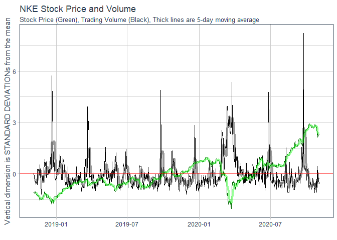

```r
adjvolNKE %>%
  ggplot() +
  geom_line(aes(x = date, y = volstd)) +
  geom_line(aes(x = date, y = adjstd), color = "dark green") +
  geom_ma(aes(x = date, y = volstd), n = 5, color = "black", size = 1.5, linetype = 1, alpha = .4) +
  geom_ma(aes(x = date, y = adjstd), n = 5, color = "green", size = 1.5, linetype = 1, alpha = .4) +
  geom_hline(yintercept = 0, color = "red") +
  labs(title = "NKE Stock Price and Volume",
       subtitle = "Stock Price (Green), Trading Volume (Black), Thick lines are 5-day moving average",
       y = "Vertical dimension is STANDARD DEVIATIONs from the mean",
       x = "") +
  theme_tq()
```

```r
adjvolT <- filter(AllMy_stockAdjVol, symbol == "T")
adjvolT
```

```
## # A tibble: 502 x 4
##    symbol date       adjusted   volume
##    <chr>  <date>        <dbl>    <dbl>
##  1 T      2018-11-05     27.0 27346500
##  2 T      2018-11-06     27.3 24310600
##  3 T      2018-11-07     27.4 30836300
##  4 T      2018-11-08     27.3 29547600
##  5 T      2018-11-09     27.0 39994700
##  6 T      2018-11-12     27.1 25935300
##  7 T      2018-11-13     26.7 25641000
##  8 T      2018-11-14     26.9 31293500
##  9 T      2018-11-15     26.5 38917400
## 10 T      2018-11-16     26.7 28929500
## # ... with 492 more rows
```

```r
adjvolT$volstd <- scale(adjvolT$volume)
adjvolT$adjstd <- scale(adjvolT$adjusted)
adjvolT
```

```
## # A tibble: 502 x 6
##    symbol date       adjusted   volume volstd[,1] adjstd[,1]
##    <chr>  <date>        <dbl>    <dbl>      <dbl>      <dbl>
##  1 T      2018-11-05     27.0 27346500     -0.521     -1.02
##  2 T      2018-11-06     27.3 24310600     -0.728     -0.936
##  3 T      2018-11-07     27.4 30836300     -0.283     -0.900
##  4 T      2018-11-08     27.3 29547600     -0.371     -0.916
##  5 T      2018-11-09     27.0 39994700      0.342     -1.01
##  6 T      2018-11-12     27.1 25935300     -0.617     -0.983
##  7 T      2018-11-13     26.7 25641000     -0.637     -1.10
##  8 T      2018-11-14     26.9 31293500     -0.252     -1.05
##  9 T      2018-11-15     26.5 38917400      0.268     -1.15
## 10 T      2018-11-16     26.7 28929500     -0.413     -1.11
## # ... with 492 more rows
```

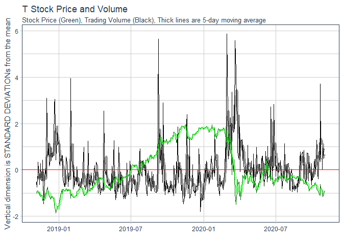

```r
adjvolT %>%
  ggplot() +
  geom_line(aes(x = date, y = volstd)) +
  geom_line(aes(x = date, y = adjstd), color = "dark green") +
  geom_ma(aes(x = date, y = volstd), n = 5, color = "black", size = 1.5, linetype = 1, alpha = .4) +
  geom_ma(aes(x = date, y = adjstd), n = 5, color = "green", size = 1.5, linetype = 1, alpha = .4) +
  geom_hline(yintercept = 0, color = "red") +
  labs(title = "T Stock Price and Volume",
       subtitle = "Stock Price (Green), Trading Volume (Black), Thick lines are 5-day moving average",
       y = "Vertical dimension is STANDARD DEVIATIONs from the mean",
       x = "") +
  theme_tq()
```

```r
adjvolWDAY <- filter(AllMy_stockAdjVol, symbol == "WDAY")
adjvolWDAY
```

```
## # A tibble: 502 x 4
##    symbol date       adjusted  volume
##    <chr>  <date>        <dbl>   <dbl>
##  1 WDAY   2018-11-05     130. 1949200
##  2 WDAY   2018-11-06     135. 1707800
##  3 WDAY   2018-11-07     144. 2952900
##  4 WDAY   2018-11-08     146. 1629100
##  5 WDAY   2018-11-09     140. 1832600
##  6 WDAY   2018-11-12     133. 2601200
##  7 WDAY   2018-11-13     135. 1627900
##  8 WDAY   2018-11-14     132. 1743100
##  9 WDAY   2018-11-15     136. 1814800
## 10 WDAY   2018-11-16     134. 1360700
## # ... with 492 more rows
```

```r
adjvolWDAY$volstd <- scale(adjvolWDAY$volume)
adjvolWDAY$adjstd <- scale(adjvolWDAY$adjusted)
adjvolWDAY
```

```
## # A tibble: 502 x 6
##    symbol date       adjusted  volume volstd[,1] adjstd[,1]
##    <chr>  <date>        <dbl>   <dbl>      <dbl>      <dbl>
##  1 WDAY   2018-11-05     130. 1949200     -0.100      -2.07
##  2 WDAY   2018-11-06     135. 1707800     -0.294      -1.88
##  3 WDAY   2018-11-07     144. 2952900      0.706      -1.50
##  4 WDAY   2018-11-08     146. 1629100     -0.358      -1.43
##  5 WDAY   2018-11-09     140. 1832600     -0.194      -1.68
##  6 WDAY   2018-11-12     133. 2601200      0.423      -1.96
##  7 WDAY   2018-11-13     135. 1627900     -0.359      -1.88
##  8 WDAY   2018-11-14     132. 1743100     -0.266      -1.98
##  9 WDAY   2018-11-15     136. 1814800     -0.208      -1.83
## 10 WDAY   2018-11-16     134. 1360700     -0.573      -1.91
## # ... with 492 more rows
```

### WDAY Recommendation: Don’t Buy, because prices are high and just turned down, and volume is coming down.

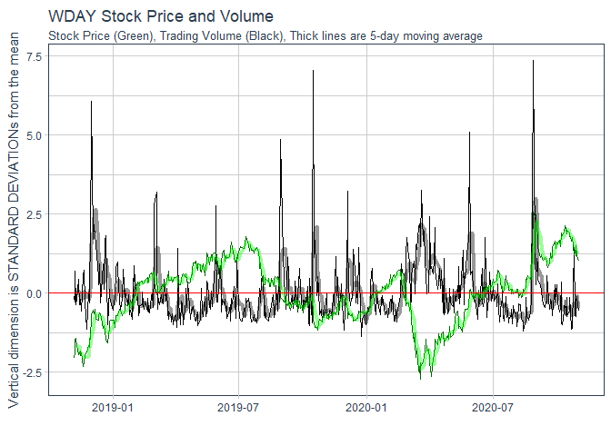

```r
adjvolWDAY %>%
  ggplot() +
  geom_line(aes(x = date, y = volstd)) +
  geom_line(aes(x = date, y = adjstd), color = "dark green") +
  geom_ma(aes(x = date, y = volstd), n = 5, color = "black", size = 1.5, linetype = 1, alpha = .4) +
  geom_ma(aes(x = date, y = adjstd), n = 5, color = "green", size = 1.5, linetype = 1, alpha = .4) +
  geom_hline(yintercept = 0, color = "red") +
  labs(title = "WDAY Stock Price and Volume",
       subtitle = "Stock Price (Green), Trading Volume (Black), Thick lines are 5-day moving average",
       y = "Vertical dimension is STANDARD DEVIATIONs from the mean",
       x = "") +
  theme_tq()
```

```r
adjvolWFC <- filter(AllMy_stockAdjVol, symbol == "WFC")
adjvolWFC
```

```
## # A tibble: 502 x 4
##    symbol date       adjusted   volume
##    <chr>  <date>        <dbl>    <dbl>
##  1 WFC    2018-11-05     49.2 18990000
##  2 WFC    2018-11-06     49.1 20696800
##  3 WFC    2018-11-07     49.1 20668500
##  4 WFC    2018-11-08     49.1 22429200
##  5 WFC    2018-11-09     49.0 18972200
##  6 WFC    2018-11-12     48.4 19003300
##  7 WFC    2018-11-13     48.7 28102000
##  8 WFC    2018-11-14     48.2 24788400
##  9 WFC    2018-11-15     48.8 23220100
## 10 WFC    2018-11-16     48.9 18872500
## # ... with 492 more rows
```

```r
adjvolWFC$volstd <- scale(adjvolWFC$volume)
adjvolWFC$adjstd <- scale(adjvolWFC$adjusted)
adjvolWFC
```

```
## # A tibble: 502 x 6
##    symbol date       adjusted   volume volstd[,1] adjstd[,1]
##    <chr>  <date>        <dbl>    <dbl>      <dbl>      <dbl>
##  1 WFC    2018-11-05     49.2 18990000    -0.644       0.984
##  2 WFC    2018-11-06     49.1 20696800    -0.541       0.974
##  3 WFC    2018-11-07     49.1 20668500    -0.543       0.977
##  4 WFC    2018-11-08     49.1 22429200    -0.437       0.978
##  5 WFC    2018-11-09     49.0 18972200    -0.645       0.967
##  6 WFC    2018-11-12     48.4 19003300    -0.643       0.903
##  7 WFC    2018-11-13     48.7 28102000    -0.0939      0.939
##  8 WFC    2018-11-14     48.2 24788400    -0.294       0.885
##  9 WFC    2018-11-15     48.8 23220100    -0.389       0.947
## 10 WFC    2018-11-16     48.9 18872500    -0.651       0.958
## # ... with 492 more rows
```

### WFC Recommendation: Buy, because prices have been low, and volume has been high for 5 months. Prices about to rebound.

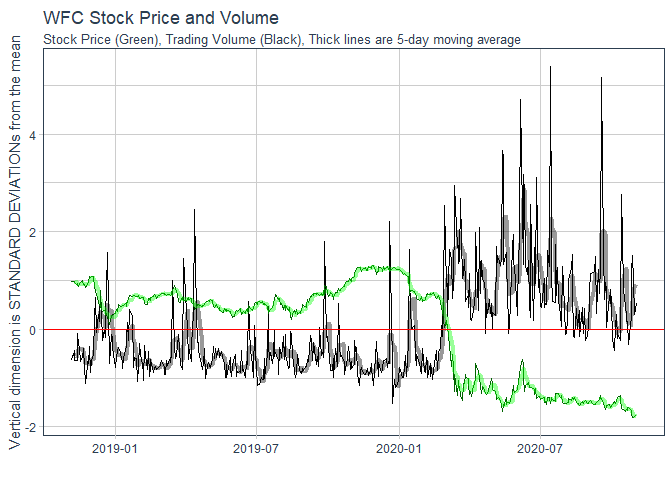

```r
adjvolWFC %>%
  ggplot() +
  geom_line(aes(x = date, y = volstd)) +
  geom_line(aes(x = date, y = adjstd), color = "dark green") +
  geom_ma(aes(x = date, y = volstd), n = 5, color = "black", size = 1.5, linetype = 1, alpha = .4) +
  geom_ma(aes(x = date, y = adjstd), n = 5, color = "green", size = 1.5, linetype = 1, alpha = .4) +
  geom_hline(yintercept = 0, color = "red") +
  labs(title = "WFC Stock Price and Volume",
         subtitle = "Stock Price (Green), Trading Volume (Black), Thick lines are 5-day moving average",
         y = "Vertical dimension is STANDARD DEVIATIONs from the mean",
         x = "") +
  theme_tq()
```

```r
adjvolWMT <- filter(AllMy_stockAdjVol, symbol == "WMT")
adjvolWMT
```

```
## # A tibble: 502 x 4
##    symbol date       adjusted   volume
##    <chr>  <date>        <dbl>    <dbl>
##  1 WMT    2018-11-05     99.0  7616800
##  2 WMT    2018-11-06     99.4  6368700
##  3 WMT    2018-11-07    100.   8672600
##  4 WMT    2018-11-08    101.   5961400
##  5 WMT    2018-11-09    102.   8450400
##  6 WMT    2018-11-12    100.   8943100
##  7 WMT    2018-11-13     99.1  7956700
##  8 WMT    2018-11-14     97.7 10481900
##  9 WMT    2018-11-15     95.8 16082600
## 10 WMT    2018-11-16     94.0 14235200
## # ... with 492 more rows
```

```r
adjvolWMT$volstd <- scale(adjvolWMT$volume)
adjvolWMT$adjstd <- scale(adjvolWMT$adjusted)
adjvolWMT
```

```
## # A tibble: 502 x 6
##    symbol date       adjusted   volume volstd[,1] adjstd[,1]
##    <chr>  <date>        <dbl>    <dbl>      <dbl>      <dbl>
##  1 WMT    2018-11-05     99.0  7616800    -0.0234     -0.969
##  2 WMT    2018-11-06     99.4  6368700    -0.308      -0.942
##  3 WMT    2018-11-07    100.   8672600     0.217      -0.876
##  4 WMT    2018-11-08    101.   5961400    -0.400      -0.839
##  5 WMT    2018-11-09    102.   8450400     0.166      -0.795
##  6 WMT    2018-11-12    100.   8943100     0.279      -0.906
##  7 WMT    2018-11-13     99.1  7956700     0.0540     -0.967
##  8 WMT    2018-11-14     97.7 10481900     0.629      -1.06
##  9 WMT    2018-11-15     95.8 16082600     1.90       -1.19
## 10 WMT    2018-11-16     94.0 14235200     1.48       -1.31
## # ... with 492 more rows
```

### WMT Recommendation: Don’t Buy, because prices are high, and volume is low after a recent peak.

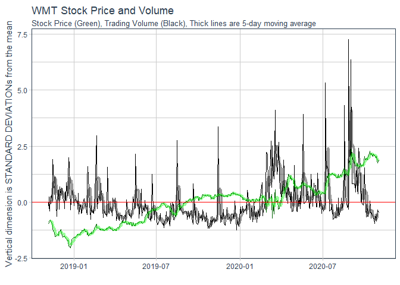

```r
adjvolWMT %>%
  ggplot() +
  geom_line(aes(x = date, y = volstd)) +
  geom_line(aes(x = date, y = adjstd), color = "dark green") +
  geom_ma(aes(x = date, y = volstd), n = 5, color = "black", size = 1.5, linetype = 1, alpha = .4) +
  geom_ma(aes(x = date, y = adjstd), n = 5, color = "green", size = 1.5, linetype = 1, alpha = .4) +
  geom_hline(yintercept = 0, color = "red") +
  labs(title = "WMT Stock Price and Volume",
       subtitle = "Stock Price (Green), Trading Volume (Black), Thick lines are 5-day moving average",
       y = "Vertical dimension is STANDARD DEVIATIONs from the mean",
       x = "") +
  theme_tq()
```